# Jaideep_Project_4

## **Description**

### Background and Context

You are a Data Scientist for a tourism company named "Visit with us". The Policy Maker of the company wants to enable and establish a viable business model to expand the customer base.

A viable business model is a central concept that helps you to understand the existing ways of doing the business and how to change the ways for the benefit of the tourism sector.

One of the ways to expand the customer base is to introduce a new offering of packages.

Currently, there are 5 types of packages the company is offering - Basic, Standard, Deluxe, Super Deluxe, King. Looking at the data of the last year, we observed that 18% of the customers purchased the packages.

However, the marketing cost was quite high because customers were contacted at random without looking at the available information.

The company is now planning to launch a new product i.e. Wellness Tourism Package. Wellness Tourism is defined as Travel that allows the traveler to maintain, enhance or kick-start a healthy lifestyle, and support or increase one's sense of well-being.

However, this time company wants to harness the available data of existing and potential customers to make the marketing expenditure more efficient.

You as a Data Scientist at "Visit with us" travel company have to analyze the customers' data and information to provide recommendations to the Policy Maker and Marketing Team and also build a model to predict the potential customer who is going to purchase the newly introduced travel package.

# **Objective**

To predict which customer is more likely to purchase the newly introduced travel package.

## **Data Dictionary**

Customer details:

- CustomerID: Unique customer ID
- ProdTaken: Whether the customer has purchased a package or not (0: No, 1: Yes)
- Age: Age of customer
- TypeofContact: How customer was contacted (Company Invited or Self Inquiry)
- CityTier: City tier depends on the development of a city, population, facilities, and living standards. The categories are ordered i.e. Tier 1 > Tier 2 > Tier 3
- Occupation: Occupation of customer
- Gender: Gender of customer
- NumberOfPersonVisiting: Total number of persons planning to take the trip with the customer
- PreferredPropertyStar: Preferred hotel property rating by customer
- MaritalStatus: Marital status of customer
- NumberOfTrips: Average number of trips in a year by customer
- Passport: The customer has a passport or not (0: No, 1: Yes)
- OwnCar: Whether the customers own a car or not (0: No, 1: Yes)
- NumberOfChildrenVisiting: Total number of children with age less than 5 planning to take the trip with the customer
- Designation: Designation of the customer in the current organization
- MonthlyIncome: Gross monthly income of the customer

# **Project Code**

```python
# Get all libraries needed for this project
import warnings
warnings.filterwarnings("ignore")

import numpy as np
import pandas as pd
import seaborn as sns
import matplotlib.pyplot as plt
from sklearn.tree import DecisionTreeClassifier
from sklearn.ensemble import BaggingClassifier,RandomForestClassifier,GradientBoostingClassifier,AdaBoostClassifier,StackingClassifier
from xgboost import XGBClassifier
from sklearn import metrics
from sklearn.model_selection import GridSearchCV, train_test_split
```

```python
# Load the data from the Excel spreadsheet that has been provided
data = pd.read_excel("Tourism.xlsx", sheet_name='Tourism')
```

## **Initial data inspection and Feature Engineering**

```python
# Take a peek at a few rows at the top
data.head()
```

|  | CustomerID | ProdTaken | Age | TypeofContact | CityTier | DurationOfPitch | Occupation | Gender | NumberOfPersonVisiting | NumberOfFollowups | ProductPitched | PreferredPropertyStar | MaritalStatus | NumberOfTrips | Passport | PitchSatisfactionScore | OwnCar | NumberOfChildrenVisiting | Designation | MonthlyIncome |
| --- | --- | --- | --- | --- | --- | --- | --- | --- | --- | --- | --- | --- | --- | --- | --- | --- | --- | --- | --- | --- |
| 0 | 200000 | 1 | 41.0 | Self Enquiry | 3 | 6.0 | Salaried | Female | 3 | 3.0 | Deluxe | 3.0 | Single | 1.0 | 1 | 2 | 1 | 0.0 | Manager | 20993.0 |
| 1 | 200001 | 0 | 49.0 | Company Invited | 1 | 14.0 | Salaried | Male | 3 | 4.0 | Deluxe | 4.0 | Divorced | 2.0 | 0 | 3 | 1 | 2.0 | Manager | 20130.0 |
| 2 | 200002 | 1 | 37.0 | Self Enquiry | 1 | 8.0 | Free Lancer | Male | 3 | 4.0 | Basic | 3.0 | Single | 7.0 | 1 | 3 | 0 | 0.0 | Executive | 17090.0 |
| 3 | 200003 | 0 | 33.0 | Company Invited | 1 | 9.0 | Salaried | Female | 2 | 3.0 | Basic | 3.0 | Divorced | 2.0 | 1 | 5 | 1 | 1.0 | Executive | 17909.0 |
| 4 | 200004 | 0 | NaN | Self Enquiry | 1 | 8.0 | Small Business | Male | 2 | 3.0 | Basic | 4.0 | Divorced | 1.0 | 0 | 5 | 1 | 0.0 | Executive | 18468.0 |

```python
# Take a peek at a few rows at the bottom
data.tail()
```

|  | CustomerID | ProdTaken | Age | TypeofContact | CityTier | DurationOfPitch | Occupation | Gender | NumberOfPersonVisiting | NumberOfFollowups | ProductPitched | PreferredPropertyStar | MaritalStatus | NumberOfTrips | Passport | PitchSatisfactionScore | OwnCar | NumberOfChildrenVisiting | Designation | MonthlyIncome |
| --- | --- | --- | --- | --- | --- | --- | --- | --- | --- | --- | --- | --- | --- | --- | --- | --- | --- | --- | --- | --- |
| 4883 | 204883 | 1 | 49.0 | Self Enquiry | 3 | 9.0 | Small Business | Male | 3 | 5.0 | Deluxe | 4.0 | Unmarried | 2.0 | 1 | 1 | 1 | 1.0 | Manager | 26576.0 |
| 4884 | 204884 | 1 | 28.0 | Company Invited | 1 | 31.0 | Salaried | Male | 4 | 5.0 | Basic | 3.0 | Single | 3.0 | 1 | 3 | 1 | 2.0 | Executive | 21212.0 |
| 4885 | 204885 | 1 | 52.0 | Self Enquiry | 3 | 17.0 | Salaried | Female | 4 | 4.0 | Standard | 4.0 | Married | 7.0 | 0 | 1 | 1 | 3.0 | Senior Manager | 31820.0 |
| 4886 | 204886 | 1 | 19.0 | Self Enquiry | 3 | 16.0 | Small Business | Male | 3 | 4.0 | Basic | 3.0 | Single | 3.0 | 0 | 5 | 0 | 2.0 | Executive | 20289.0 |
| 4887 | 204887 | 1 | 36.0 | Self Enquiry | 1 | 14.0 | Salaried | Male | 4 | 4.0 | Basic | 4.0 | Unmarried | 3.0 | 1 | 3 | 1 | 2.0 | Executive | 24041.0 |

```python
# Let's get some more info on the data itself
data.info()
```

```
<class 'pandas.core.frame.DataFrame'>
RangeIndex: 4888 entries, 0 to 4887
Data columns (total 20 columns):
 #   Column                    Non-Null Count  Dtype
---  ------                    --------------  -----
 0   CustomerID                4888 non-null   int64
 1   ProdTaken                 4888 non-null   int64
 2   Age                       4662 non-null   float64
 3   TypeofContact             4863 non-null   object
 4   CityTier                  4888 non-null   int64
 5   DurationOfPitch           4637 non-null   float64
 6   Occupation                4888 non-null   object
 7   Gender                    4888 non-null   object
 8   NumberOfPersonVisiting    4888 non-null   int64
 9   NumberOfFollowups         4843 non-null   float64
 10  ProductPitched            4888 non-null   object
 11  PreferredPropertyStar     4862 non-null   float64
 12  MaritalStatus             4888 non-null   object
 13  NumberOfTrips             4748 non-null   float64
 14  Passport                  4888 non-null   int64
 15  PitchSatisfactionScore    4888 non-null   int64
 16  OwnCar                    4888 non-null   int64
 17  NumberOfChildrenVisiting  4822 non-null   float64
 18  Designation               4888 non-null   object
 19  MonthlyIncome             4655 non-null   float64
dtypes: float64(7), int64(7), object(6)
memory usage: 763.9+ KB
```

There are 4888 rows of data with 20 columns.

The target variable in this case is `'ProdTaken'`, which indicates whether the customer bought a package or not.

A lot of the data entries are actually categorical data, for which we will need to do some pre-processing to convert the string values to numerical data.

1. TypeofContact
2. Occupation
3. Gender
4. ProductPitched
5. MaritalStatus
6. Designation

There are other columns that are categorical with numeric data.

1. ProdTaken (target variable)
2. CityTier
3. PreferredPropertyStar
4. Passport
5. OwnCar

The following columns are numerical and continuous.

1. Age
2. DurationOfPitch
3. NumberOfPersonVisiting
4. NumberOfFollowups
5. NumberOfTrips
6. PitchSatisfactionScore
7. NumberOfChildrenVisiting
8. MonthlyIncome

The `'CustomerID'` is a unique identifier for a customer and doesn't have much bearing on the outcome, hence it can be dropped at some point.

There appear to be a few columns with less than 4888 number of non-null rows of data. So, there is some missing data. We can verify using the isna() function call.

```python
data.isna().sum()
```

```
CustomerID                    0
ProdTaken                     0
Age                         226
TypeofContact                25
CityTier                      0
DurationOfPitch             251
Occupation                    0
Gender                        0
NumberOfPersonVisiting        0
NumberOfFollowups            45
ProductPitched                0
PreferredPropertyStar        26
MaritalStatus                 0
NumberOfTrips               140
Passport                      0
PitchSatisfactionScore        0
OwnCar                        0
NumberOfChildrenVisiting     66
Designation                   0
MonthlyIncome               233
dtype: int64
```

Here is what we can do about the missing values:

1. For the numeric data, we can impute a median value for the missing data. This applies to 'Age', 'DurationOfPitch', 'NumberOfFollowups', 'NumberOfTrips', 'NumberOfChildrenVisiting', 'MonthlyIncome'.
2. The 'PreferredPropertyStar' column is really a categorical column with data in numeric form, so imputing it with a median number makes less sense. Since there are only 26 missing data, we can drop these rows.
3. 'TypeofContact' is categorical data with only 25 missing data. Drop these rows as well.

```python
# Summary of continuous columns
data[['Age','DurationOfPitch','NumberOfPersonVisiting','NumberOfFollowups', 'NumberOfTrips', 'PitchSatisfactionScore', 'NumberOfChildrenVisiting', 'MonthlyIncome']].describe().T
```

|  | count | mean | std | min | 25% | 50% | 75% | max |
| --- | --- | --- | --- | --- | --- | --- | --- | --- |
| Age | 4662.0 | 37.622265 | 9.316387 | 18.0 | 31.0 | 36.0 | 44.0 | 61.0 |
| DurationOfPitch | 4637.0 | 15.490835 | 8.519643 | 5.0 | 9.0 | 13.0 | 20.0 | 127.0 |
| NumberOfPersonVisiting | 4888.0 | 2.905074 | 0.724891 | 1.0 | 2.0 | 3.0 | 3.0 | 5.0 |
| NumberOfFollowups | 4843.0 | 3.708445 | 1.002509 | 1.0 | 3.0 | 4.0 | 4.0 | 6.0 |
| NumberOfTrips | 4748.0 | 3.236521 | 1.849019 | 1.0 | 2.0 | 3.0 | 4.0 | 22.0 |
| PitchSatisfactionScore | 4888.0 | 3.078151 | 1.365792 | 1.0 | 2.0 | 3.0 | 4.0 | 5.0 |
| NumberOfChildrenVisiting | 4822.0 | 1.187267 | 0.857861 | 0.0 | 1.0 | 1.0 | 2.0 | 3.0 |
| MonthlyIncome | 4655.0 | 23619.853491 | 5380.698361 | 1000.0 | 20346.0 | 22347.0 | 25571.0 | 98678.0 |

```python
# Number of unique values for the categorical columns
data.nunique()
```

```
CustomerID                  4888
ProdTaken                      2
Age                           44
TypeofContact                  2
CityTier                       3
DurationOfPitch               34
Occupation                     4
Gender                         3
NumberOfPersonVisiting         5
NumberOfFollowups              6
ProductPitched                 5
PreferredPropertyStar          3
MaritalStatus                  4
NumberOfTrips                 12
Passport                       2
PitchSatisfactionScore         5
OwnCar                         2
NumberOfChildrenVisiting       4
Designation                    5
MonthlyIncome               2475
dtype: int64
```

##### An analysis of the unique values for the categorical columns tells us the following:

1. ProdTaken is either 1 or 0, representing True/False.
2. Only 2 types of TypeOfContact
3. Only 3 types of city tiers.
4. Only 4 unique occupations
5. 3 types of genders -- I will assume that the third gender is intentional
6. 5 types of products were pitched
7. Only 3 distinct property stars
8. 4 different marital status
9. Passport is a True/False indicator
10. OwnCar is a True/False indicator
11. 5 different designations

##### Next, we can look at these different values themselves

```python
cat_cols=['ProdTaken','TypeofContact','Occupation','Gender','ProductPitched','MaritalStatus','Designation','CityTier','PreferredPropertyStar','Passport','OwnCar']

for column in cat_cols:
    print(data[column].value_counts())
    print('-'*30)
```

```
0    3968
1     920
Name: ProdTaken, dtype: int64
------------------------------
Self Enquiry       3444
Company Invited    1419
Name: TypeofContact, dtype: int64
------------------------------
Salaried          2368
Small Business    2084
Large Business     434
Free Lancer          2
Name: Occupation, dtype: int64
------------------------------
Male       2916
Female     1817
Fe Male     155
Name: Gender, dtype: int64
------------------------------
Basic           1842
Deluxe          1732
Standard         742
Super Deluxe     342
King             230
Name: ProductPitched, dtype: int64
------------------------------
Married      2340
Divorced      950
Single        916
Unmarried     682
Name: MaritalStatus, dtype: int64
------------------------------
Executive         1842
Manager           1732
Senior Manager     742
AVP                342
VP                 230
Name: Designation, dtype: int64
------------------------------
1    3190
3    1500
2     198
Name: CityTier, dtype: int64
------------------------------
3.0    2993
5.0     956
4.0     913
Name: PreferredPropertyStar, dtype: int64
------------------------------
0    3466
1    1422
Name: Passport, dtype: int64
------------------------------
1    3032
0    1856
Name: OwnCar, dtype: int64
------------------------------
```

### **Now for some data cleanup**

```python
# Drop customer Id
data.drop(columns=['CustomerID'], inplace=True)
```

```python
# Drop the data for missing data for 'TypeofContact' and 'PreferredPropertyStar'
data.dropna(subset=["TypeofContact", "PreferredPropertyStar"], inplace=True)
```

```python
data.info()
```

```
<class 'pandas.core.frame.DataFrame'>
Int64Index: 4837 entries, 0 to 4887
Data columns (total 19 columns):
 #   Column                    Non-Null Count  Dtype
---  ------                    --------------  -----
 0   ProdTaken                 4837 non-null   int64
 1   Age                       4611 non-null   float64
 2   TypeofContact             4837 non-null   object
 3   CityTier                  4837 non-null   int64
 4   DurationOfPitch           4611 non-null   float64
 5   Occupation                4837 non-null   object
 6   Gender                    4837 non-null   object
 7   NumberOfPersonVisiting    4837 non-null   int64
 8   NumberOfFollowups         4792 non-null   float64
 9   ProductPitched            4837 non-null   object
 10  PreferredPropertyStar     4837 non-null   float64
 11  MaritalStatus             4837 non-null   object
 12  NumberOfTrips             4697 non-null   float64
 13  Passport                  4837 non-null   int64
 14  PitchSatisfactionScore    4837 non-null   int64
 15  OwnCar                    4837 non-null   int64
 16  NumberOfChildrenVisiting  4771 non-null   float64
 17  Designation               4837 non-null   object
 18  MonthlyIncome             4629 non-null   float64
dtypes: float64(7), int64(6), object(6)
memory usage: 755.8+ KB
```

**Note** We started off with 4888 rows of data. After dropping the rows with missing data, we are still left with 4837 rows, which means we only dropped 51 records, or a mere 1% of records.

```python
# Now we need to impute some of the continuous numerical data by replacing them with median values
numeric_cols = ['Age','DurationOfPitch','NumberOfFollowups','NumberOfTrips','NumberOfChildrenVisiting','MonthlyIncome']
data[numeric_cols] = data[numeric_cols].transform(lambda x: x.fillna(x.median()))
data.isna().sum()
```

```
ProdTaken                   0
Age                         0
TypeofContact               0
CityTier                    0
DurationOfPitch             0
Occupation                  0
Gender                      0
NumberOfPersonVisiting      0
NumberOfFollowups           0
ProductPitched              0
PreferredPropertyStar       0
MaritalStatus               0
NumberOfTrips               0
Passport                    0
PitchSatisfactionScore      0
OwnCar                      0
NumberOfChildrenVisiting    0
Designation                 0
MonthlyIncome               0
dtype: int64
```

```python
data.info()
```

```
<class 'pandas.core.frame.DataFrame'>
Int64Index: 4837 entries, 0 to 4887
Data columns (total 19 columns):
 #   Column                    Non-Null Count  Dtype
---  ------                    --------------  -----
 0   ProdTaken                 4837 non-null   int64
 1   Age                       4837 non-null   float64
 2   TypeofContact             4837 non-null   object
 3   CityTier                  4837 non-null   int64
 4   DurationOfPitch           4837 non-null   float64
 5   Occupation                4837 non-null   object
 6   Gender                    4837 non-null   object
 7   NumberOfPersonVisiting    4837 non-null   int64
 8   NumberOfFollowups         4837 non-null   float64
 9   ProductPitched            4837 non-null   object
 10  PreferredPropertyStar     4837 non-null   float64
 11  MaritalStatus             4837 non-null   object
 12  NumberOfTrips             4837 non-null   float64
 13  Passport                  4837 non-null   int64
 14  PitchSatisfactionScore    4837 non-null   int64
 15  OwnCar                    4837 non-null   int64
 16  NumberOfChildrenVisiting  4837 non-null   float64
 17  Designation               4837 non-null   object
 18  MonthlyIncome             4837 non-null   float64
dtypes: float64(7), int64(6), object(6)
memory usage: 755.8+ KB
```

We now have confirmation that there are no missing values in the data.

```python
# Let's reinspect all of the continuous columns
data[['Age','DurationOfPitch','NumberOfPersonVisiting','NumberOfFollowups', 'NumberOfTrips', 'PitchSatisfactionScore', 'NumberOfChildrenVisiting', 'MonthlyIncome']].describe().T
```

|  | count | mean | std | min | 25% | 50% | 75% | max |
| --- | --- | --- | --- | --- | --- | --- | --- | --- |
| Age | 4837.0 | 37.516229 | 9.069167 | 18.0 | 31.0 | 36.0 | 43.0 | 61.0 |
| DurationOfPitch | 4837.0 | 15.380401 | 8.336915 | 5.0 | 9.0 | 13.0 | 19.0 | 127.0 |
| NumberOfPersonVisiting | 4837.0 | 2.904900 | 0.724191 | 1.0 | 2.0 | 3.0 | 3.0 | 5.0 |
| NumberOfFollowups | 4837.0 | 3.708910 | 0.994832 | 1.0 | 3.0 | 4.0 | 4.0 | 6.0 |
| NumberOfTrips | 4837.0 | 3.224933 | 1.820483 | 1.0 | 2.0 | 3.0 | 4.0 | 22.0 |
| PitchSatisfactionScore | 4837.0 | 3.076907 | 1.366123 | 1.0 | 2.0 | 3.0 | 4.0 | 5.0 |
| NumberOfChildrenVisiting | 4837.0 | 1.183998 | 0.850758 | 0.0 | 1.0 | 1.0 | 2.0 | 3.0 |
| MonthlyIncome | 4837.0 | 23471.238991 | 5071.299404 | 1000.0 | 20470.0 | 22295.0 | 25374.0 | 98678.0 |

#### It is now time to replace all the categorical string data with numeric data.

The following columns need to be processed.

- TypeofContact
- Occupation
- Gender
- ProductPitched
- MaritalStatus
- Designation

```python
# Let's cleanup the TypeofContact column. Put the numeric values in a separate column. We will drop the original object column later.
def getNumericContact(x):
    if ( x == 'Self Enquiry' ):
        return 0
    else:
        return 1

data['TypeofContact_num'] = data['TypeofContact'].apply(getNumericContact)
print(data['TypeofContact'].value_counts())
print(data['TypeofContact_num'].value_counts())
```

```
Self Enquiry       3422
Company Invited    1415
Name: TypeofContact, dtype: int64
0    3422
1    1415
Name: TypeofContact_num, dtype: int64
```

```python
# Let's cleanup the Occupation column. Put the numeric values in a separate column. We will drop the original object column later.
def getNumericOccupation(x):
    if ( x == 'Salaried' ):
        return 0
    elif ( x == 'Small Business'):
        return 1
    elif ( x == 'Large Business'):
        return 2
    else:
        return 3

data['Occupation_num'] = data['Occupation'].apply(getNumericOccupation)
print(data['Occupation'].value_counts())
print(data['Occupation_num'].value_counts())
```

```
Salaried          2347
Small Business    2056
Large Business     432
Free Lancer          2
Name: Occupation, dtype: int64
0    2347
1    2056
2     432
3       2
Name: Occupation_num, dtype: int64
```

```python
# Let's cleanup the Gender column. Put the numeric values in a separate column. We will drop the original object column later.
def getNumericGender(x):
    if ( x == 'Male' ):
        return 0
    elif ( x == 'Female'):
        return 1
    else:
        return 2

data['Gender_num'] = data['Gender'].apply(getNumericGender)
print(data['Gender'].value_counts())
print(data['Gender_num'].value_counts())
```

```
Male       2887
Female     1795
Fe Male     155
Name: Gender, dtype: int64
0    2887
1    1795
2     155
Name: Gender_num, dtype: int64
```

```python
# Let's cleanup the ProductPitched column. Put the numeric values in a separate column. We will drop the original object column later.
def getNumericProduct(x):
    if ( x == 'Basic' ):
        return 0
    elif ( x == 'Deluxe'):
        return 1
    elif ( x == 'Standard'):
        return 2
    elif ( x == 'Super Deluxe'):
        return 3
    else:
        return 4

data['ProductPitched_num'] = data['ProductPitched'].apply(getNumericProduct)
print(data['ProductPitched'].value_counts())
print(data['ProductPitched_num'].value_counts())
```

```
Basic           1831
Deluxe          1716
Standard         741
Super Deluxe     342
King             207
Name: ProductPitched, dtype: int64
0    1831
1    1716
2     741
3     342
4     207
Name: ProductPitched_num, dtype: int64
```

```python
# Let's cleanup the MaritalStatus column. Put the numeric values in a separate column. We will drop the original object column later.
def getNumericMaritalStatus(x):
    if ( x == 'Married' ):
        return 0
    elif ( x == 'Divorced'):
        return 1
    elif ( x == 'Single'):
        return 2
    else:
        return 3

data['MaritalStatus_num'] = data['MaritalStatus'].apply(getNumericMaritalStatus)
print(data['MaritalStatus'].value_counts())
print(data['MaritalStatus_num'].value_counts())
```

```
Married      2311
Divorced      938
Single        906
Unmarried     682
Name: MaritalStatus, dtype: int64
0    2311
1     938
2     906
3     682
Name: MaritalStatus_num, dtype: int64
```

```python
# Let's cleanup the Designation column. Put the numeric values in a separate column. We will drop the original object column later.
def getNumericDesignation(x):
    if ( x == 'Executive' ):
        return 0
    elif ( x == 'Manager'):
        return 1
    elif ( x == 'Senior Manager'):
        return 2
    elif ( x == 'AVP'):
        return 3
    else:
        return 4

data['Designation_num'] = data['Designation'].apply(getNumericDesignation)
print(data['Designation'].value_counts())
print(data['Designation_num'].value_counts())
```

```
Executive         1831
Manager           1716
Senior Manager     741
AVP                342
VP                 207
Name: Designation, dtype: int64
0    1831
1    1716
2     741
3     342
4     207
Name: Designation_num, dtype: int64
```

```python
# Now let's drop all the categorical object columns
cols_to_drop = ['TypeofContact','Occupation','Gender','ProductPitched','MaritalStatus','Designation']
data.drop(columns=cols_to_drop, inplace=True)
```

```python
data.info()
```

```
<class 'pandas.core.frame.DataFrame'>
Int64Index: 4837 entries, 0 to 4887
Data columns (total 19 columns):
 #   Column                    Non-Null Count  Dtype
---  ------                    --------------  -----
 0   ProdTaken                 4837 non-null   int64
 1   Age                       4837 non-null   float64
 2   CityTier                  4837 non-null   int64
 3   DurationOfPitch           4837 non-null   float64
 4   NumberOfPersonVisiting    4837 non-null   int64
 5   NumberOfFollowups         4837 non-null   float64
 6   PreferredPropertyStar     4837 non-null   float64
 7   NumberOfTrips             4837 non-null   float64
 8   Passport                  4837 non-null   int64
 9   PitchSatisfactionScore    4837 non-null   int64
 10  OwnCar                    4837 non-null   int64
 11  NumberOfChildrenVisiting  4837 non-null   float64
 12  MonthlyIncome             4837 non-null   float64
 13  TypeofContact_num         4837 non-null   int64
 14  Occupation_num            4837 non-null   int64
 15  Gender_num                4837 non-null   int64
 16  ProductPitched_num        4837 non-null   int64
 17  MaritalStatus_num         4837 non-null   int64
 18  Designation_num           4837 non-null   int64
dtypes: float64(7), int64(12)
memory usage: 755.8 KB
```

### We are done with all the cleanup. We have no more categorical data in non-numeric format, and we have no missing data at this point. Further analysis can now proceed.

```python
## Exploratory Data Analysis
```

# **Exploratory Data Analysis**

## **Univariate Analysis**

For the purpose of univariate analysis, I will copy a couple of utility functions that have been used in MLS sessions instead of trying to create my own.

```python
# >>>> The following code has been borrowed from MLS sessions <<<<<

# While doing uni-variate analysis of numerical variables we want to study their central tendency
# and dispersion.
# Let us write a function that will help us create boxplot and histogram for any input numerical
# variable.
# This function takes the numerical column as the input and returns the boxplots
# and histograms for the variable.

def histogram_boxplot(feature, figsize=(15,10), bins = None):
    """ Boxplot and histogram combined
    feature: 1-d feature array
    figsize: size of fig (default (9,8))
    bins: number of bins (default None / auto)
    """
    f2, (ax_box2, ax_hist2) = plt.subplots(nrows = 2, # Number of rows of the subplot grid= 2
                                           sharex = True, # x-axis will be shared among all subplots
                                           gridspec_kw = {"height_ratios": (.25, .75)},
                                           figsize = figsize
                                           ) # creating the 2 subplots
    sns.boxplot(feature, ax=ax_box2, showmeans=True, color='violet') # boxplot will be created and a star will indicate the mean value of the column
    sns.distplot(feature, kde=F, ax=ax_hist2, bins=bins,palette="winter") if bins else sns.distplot(feature, kde=False, ax=ax_hist2) # For histogram
    ax_hist2.axvline(np.mean(feature), color='green', linestyle='--') # Add mean to the histogram
    ax_hist2.axvline(np.median(feature), color='black', linestyle='-') # Add median to the histogram
```

```python
# >>>> The following code has been borrowed from MLS sessions <<<<<

def perc_on_bar(feature):
    '''
    plot
    feature: categorical feature
    the function won't work if a column is passed in hue parameter
    '''
    #Creating a countplot for the feature
    sns.set(rc={'figure.figsize':(15,7)})
    ax=sns.countplot(x=feature, data=data)

    total = len(feature) # length of the column
    for p in ax.patches:
        percentage = '{:.1f}%'.format(100 * p.get_height()/total) # percentage of each class of the category
        x = p.get_x() + p.get_width() / 2 - 0.25 # width of the plot
        y = p.get_y() + p.get_height()           # hieght of the plot
        ax.annotate(percentage, (x, y), size = 14) # annotate the percantage

    plt.show() # show the plot
```

### Univariate analysis of continuous variables

1. Age
2. DurationOfPitch
3. MonthlyIncome

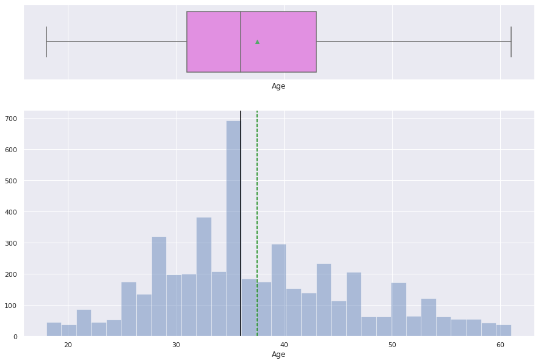

```python
# Plot of Age
histogram_boxplot(data.Age)
```

The Age data is normally distributed with the greatest concentration around middle to late 30s. There aren't outliers in the data. The customers range from teenagers all the way to people slightly above 60.

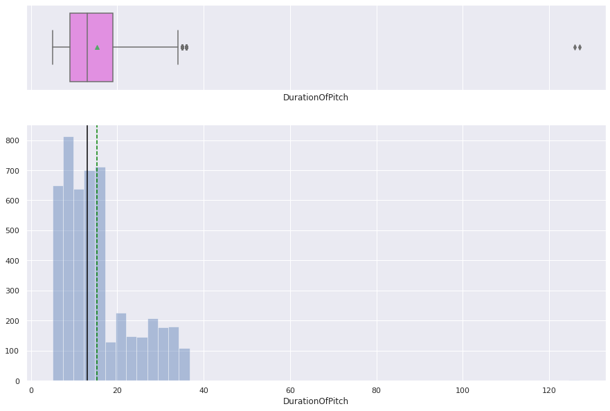

```python
# Plot of DurationOfPitch
histogram_boxplot(data.DurationOfPitch)
```

If you ignore the outliers, most of the sales pitches to customers range between 10 minutes to about 35 minutes, with a majority of them under 20 minutes.

Some pitches have gone as long as over 2 hours, but they are the outliers.

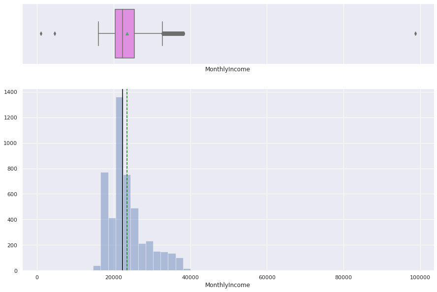

```python
# Plot of MonthlyIncome
histogram_boxplot(data.MonthlyIncome)
```

Most monthly incomes fall tightly between 15,000 and 40,000 with a majority of them around the 20,000 mark. There are some outliers on either end - the numbers close to 0 could be data errors.

### Univariate analysis of non-continuous numeric variables and categorical variables

1. NumberOfPersonVisiting
2. NumberOfFollowups
3. NumberOfTrips
4. PitchSatisfactionScore
5. NumberOfChildrenVisiting

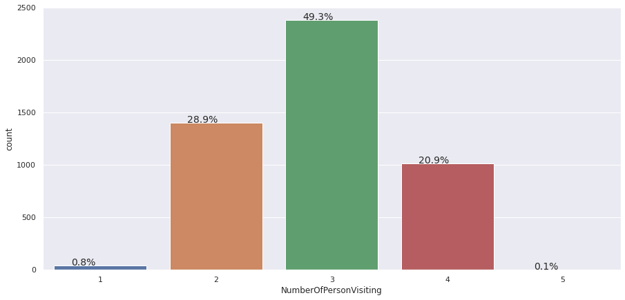

```python
perc_on_bar(data.NumberOfPersonVisiting)
```

49.3% of the time, people travel in groups of 3, followed by 28.9% of time people traveling as couples. There are groups of 4 as well 20.9% of the time, but very few people travel alone.

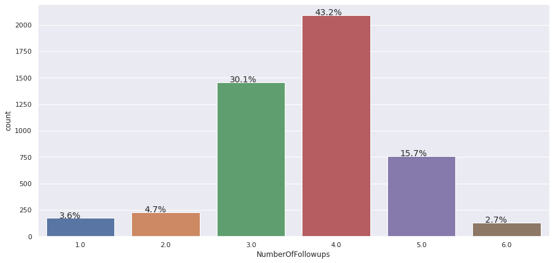

```python
perc_on_bar(data.NumberOfFollowups)
```

The sales team has been diligent with followups with customers, with 43.2% of the customers have been followed up 4 times. If we see followups of 4 and above, then 60% of customers have been followed up.

This implies that customers do not tend to buy travel packages unless there is plenty of followup from sales teams.

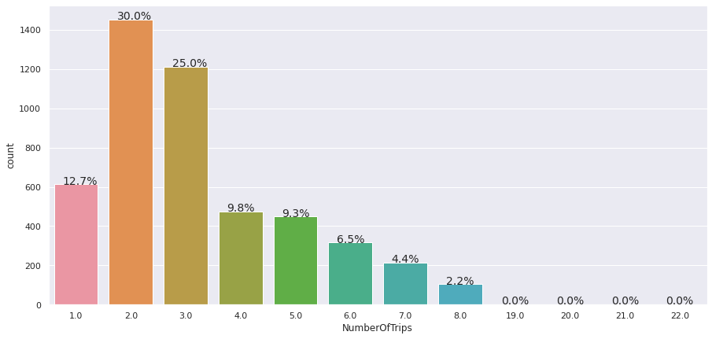

```python
perc_on_bar(data.NumberOfTrips)
```

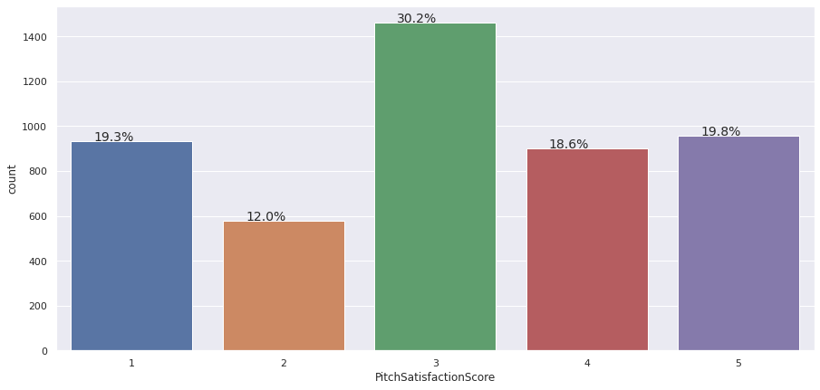

```python
perc_on_bar(data.PitchSatisfactionScore)
```

The sales pitch satisfaction score is fairly evenly ditributed with a score of 3 being the mode. About 38% of people have given a rating of 4 or above to the sales pitches, which means that the sales team is doing a good job with their pitches.

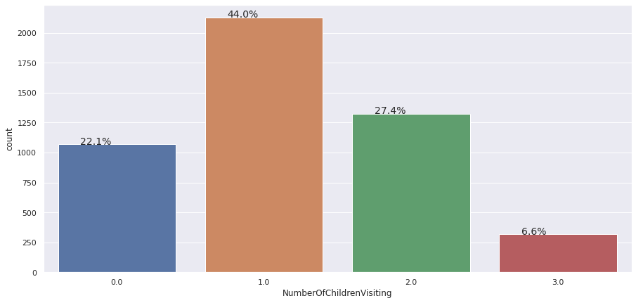

```python
perc_on_bar(data.NumberOfChildrenVisiting)
```

The number of children visiting has a mode of 1, with 44% of cases covered by that. This is followed by 2 children in 27.4% of cases, and no children in 22% of cases. This is a normal distribution.

## **Bivariate Analysis**

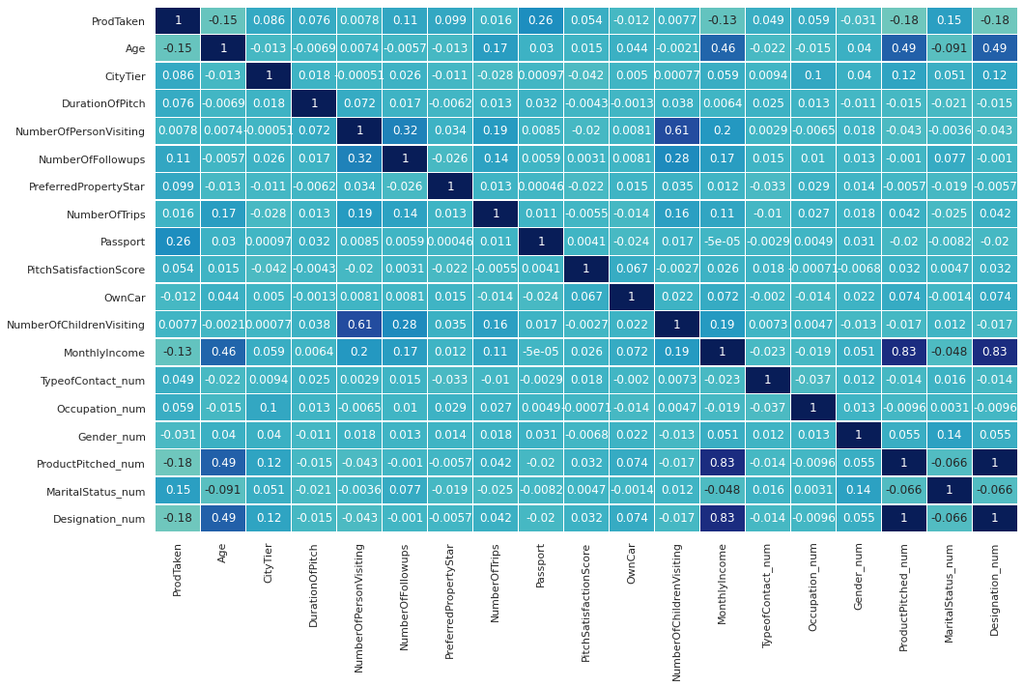

```python
# Let's do a heatmap to see if there is correlation between the various features that we need to be worried about
sns.set(rc={'figure.figsize':(16,10)})
sns.heatmap(data.corr(),
            annot=True,
            linewidths=.5,
            center=0,
            cbar=False,
            cmap="YlGnBu")
plt.show()
```

The Heatmap shows the following

1. There is a perfect correlation between ProductPitched_num and Designation_num. We will need to drop one of the features -- we will drop 'Designation_num'.
2. There is a strong correlation of 0.83 between MonthlyIncome and ProductPitched_num. I will drop the ProductPitched_num column since it appears that the kind of product pitched depends on the monthly income of a customer.
3. There is a strong correlation of 0.61 between NumberOfPersonVisiting and NumberOfChildrenVisiting. I will drop the NumberOfChildrenVisiting column.

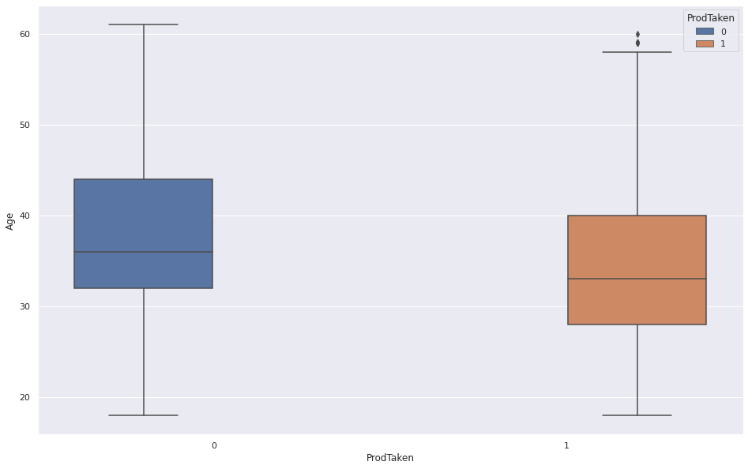

```python
# Let's look at a distribution of age for those who purchase travel package vs. those who don't
sns.boxplot(x=data.ProdTaken, y=data.Age, hue=data.ProdTaken);
```

While there is a big overlap of age between people who buy travel package and those who don't, some patterns emerge.

1. People over 40 are less likely to buy travel packages.
2. People in their late 20s and early 30s tend to buy travel packages.

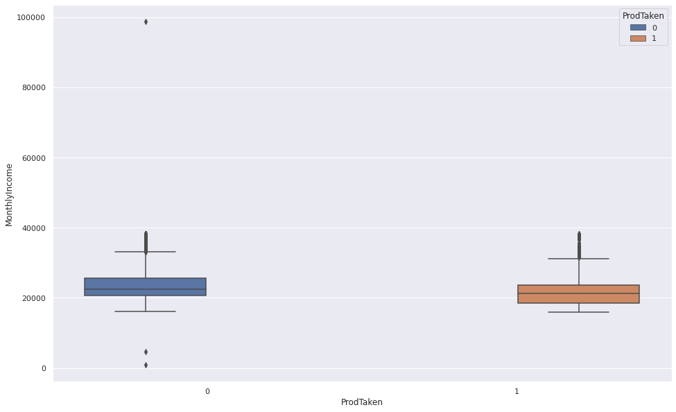

```python
# Let's look at a distribution of monthly income for those who purchase travel package vs. those who don't
sns.boxplot(x=data.ProdTaken, y=data.MonthlyIncome, hue=data.ProdTaken);
```

There isn't much to choose from here. The monthly income doesn't appear to greatly influence who buys a travel package and who doesn't.

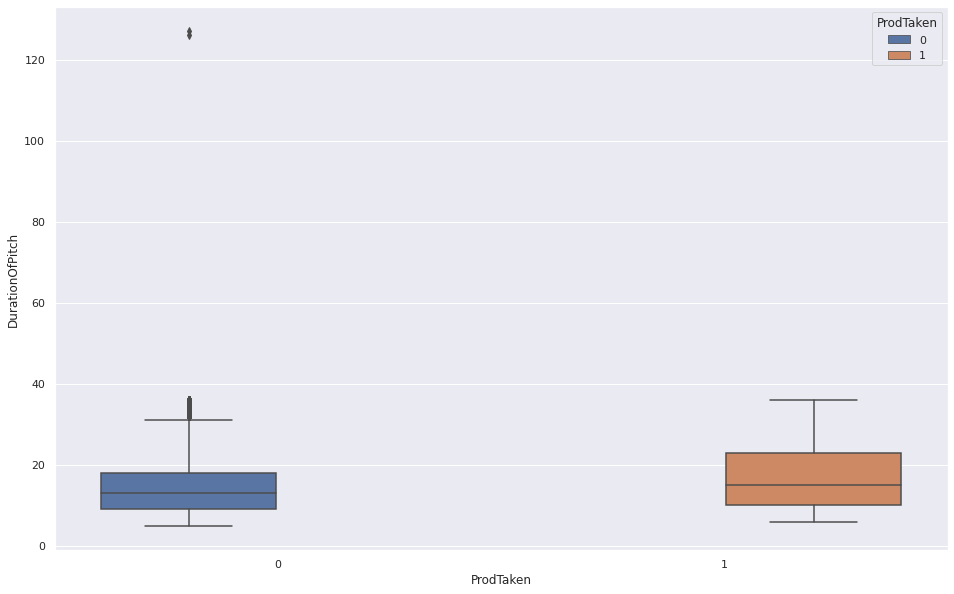

```python
# Let's look at a distribution of duration of pitch for those who purchase travel package vs. those who don't
sns.boxplot(x=data.ProdTaken, y=data.DurationOfPitch, hue=data.ProdTaken);
```

This plot shows that although shorter duration pitches don't influence travel package buying decision, pitches between 20 to 30 minutes appear to swing people more towards buying a package.

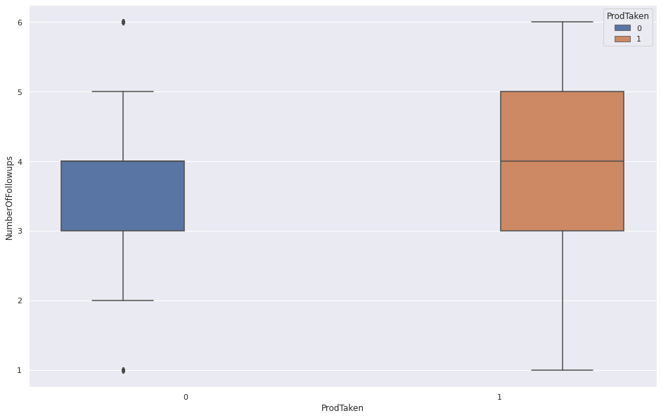

```python
# Let's look at a distribution of number of followups for those who purchase travel package vs. those who don't
sns.boxplot(x=data.ProdTaken, y=data.NumberOfFollowups, hue=data.ProdTaken);
```

Number of follow ups appears to have a significant impact, especially if there are 4-5 followups.

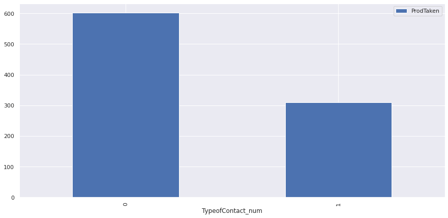

```python
sns.set(rc={'figure.figsize':(15,7)})
pd.pivot_table(data=data, index=['TypeofContact_num'], values='ProdTaken', aggfunc=np.sum).plot(kind='bar');
```

Used a pivot table to count the different types of contacts that have led to people buying a travel package. This shows that contact type of 0, which corresponds to 'Self Enquiry' has resulted in more travel packages getting bought.

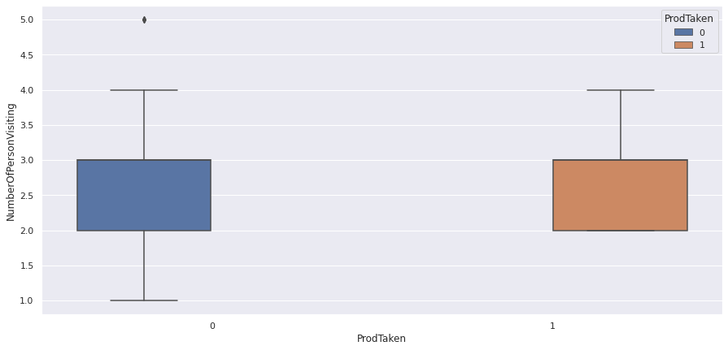

```python
# Let's look at a distribution of number of persons visiting for those who purchase travel package vs. those who don't
sns.boxplot(x=data.ProdTaken, y=data.NumberOfPersonVisiting, hue=data.ProdTaken);
```

This boxplot indicates that the number of people visiting does not seem to have much impact on whether people will buy travel package.

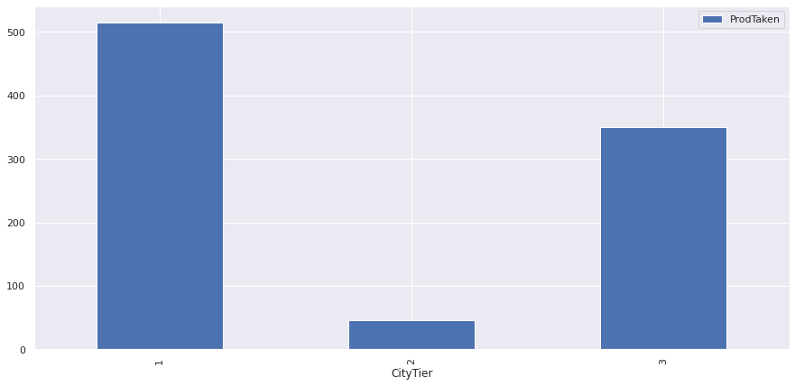

```python
sns.set(rc={'figure.figsize':(15,7)})
pd.pivot_table(data=data, index=['CityTier'], values='ProdTaken', aggfunc=np.sum).plot(kind='bar');
```

# **Summary of EDA**

- Age is normally distributed with customers ranging from teens to lower 60s.
- Median and mean income for customers is in the 15-16K range, although there are a few customers making more than 100K and they are outliers.
- Most passengers require multiple followups before they buy travel package.
- Travel packages are more likely to be bought by customers who did a self enquiry. This means company invited customers are not interested in travel packages (perhaps because company is paying for travel).
- Travel packages are bought by people in Tier 1 and 3 cities, but not from Tier 2 cities. This needs investigation.
- Duration of sales pitch appears to have an impact on sales, provided it is 20 minutes or more of sales pitch.
- Age has an influence on travel package sales. Older people, especially over 40, tend not to buy travel packages as much.
- Designation and product pitched to them has a strong correlation, which needs to be handled through feature engineering.

## **Some more data cleanup to drop the set of correlated features**

1. Designation_num
2. ProductPitched_num
3. NumberOfChildrenVisiting

```python
cols_to_drop = ['Designation_num','ProductPitched_num','NumberOfChildrenVisiting']
data.drop(columns=cols_to_drop, inplace=True)
```

```python
# Final data inspection prior to building the models
data.info()
```

```
<class 'pandas.core.frame.DataFrame'>
Int64Index: 4837 entries, 0 to 4887
Data columns (total 16 columns):
 #   Column                  Non-Null Count  Dtype
---  ------                  --------------  -----
 0   ProdTaken               4837 non-null   int64
 1   Age                     4837 non-null   float64
 2   CityTier                4837 non-null   int64
 3   DurationOfPitch         4837 non-null   float64
 4   NumberOfPersonVisiting  4837 non-null   int64
 5   NumberOfFollowups       4837 non-null   float64
 6   PreferredPropertyStar   4837 non-null   float64
 7   NumberOfTrips           4837 non-null   float64
 8   Passport                4837 non-null   int64
 9   PitchSatisfactionScore  4837 non-null   int64
 10  OwnCar                  4837 non-null   int64
 11  MonthlyIncome           4837 non-null   float64
 12  TypeofContact_num       4837 non-null   int64
 13  Occupation_num          4837 non-null   int64
 14  Gender_num              4837 non-null   int64
 15  MaritalStatus_num       4837 non-null   int64
dtypes: float64(6), int64(10)
memory usage: 802.4 KB
```

```python
data.ProdTaken.value_counts()
```

```
0    3926
1     911
Name: ProdTaken, dtype: int64
```

# **Split up the data into training and testing set**

```python
# Separating features and the target column
X = data.drop('ProdTaken', axis=1)
y = data['ProdTaken']
```

```python
# Splitting the data into train and test sets in 70:30 ratio
X_train, X_test, y_train, y_test = train_test_split(X, y, test_size=0.30, random_state=1, shuffle=True)
```

```python
# Verify that the two datasets have been split up in the 70:30 ratio
X_train.shape, X_test.shape
```

```
((3385, 15), (1452, 15))
```

The training set has 3385 records, while the testing set has 1452 records. This is out of a total of 4837 records, which makes it truly a 70/30 split.

# **Now build different models, analyze results, and then improve the model**

### In order to analyze the effectiveness of the model, I am going to copy some utility functions shown in MLS sessions and adapt them to create displays in the format that I need.

```python
def showScores(y_actual, y_pred, type="Training") :
    '''
    A utility function to display the scores for either a test set or for a training set.
    Caller should send predicted and actual Y values for either a test set or for a training set, but not both.
    '''
    accuracy = metrics.accuracy_score(y_actual, y_pred)
    precision = metrics.precision_score(y_actual, y_pred)
    recall = metrics.recall_score(y_actual, y_pred)
    f1 = metrics.f1_score(y_actual, y_pred)

    print(type + " Set >>>>")
    print(f"       Accuracy: {accuracy}")
    print(f"       Recall: {recall}")
    print(f"       Precision: {precision}")
    print(f"       F1: {f1}")
    print(f"       R-square: {metrics.r2_score(y_actual,y_pred)}")
    print(f"       RMSE: {np.sqrt(metrics.mean_squared_error(y_actual,y_pred))}")
```

```python
# >>>> The following code has been borrowed from MLS sessions, and then I have enhanced it <<<<<

##  Function to calculate r2_score, RMSE, accuracy, recall, and precision on train and test data
def get_model_score(model, flag=True):
    '''
    model : classifier to predict values of X

    '''
    # defining an empty list to store train and test results
    score_list=[]

    pred_train = model.predict(X_train)
    pred_test = model.predict(X_test)

    # My adaptation of the original code goes here.
    showScores(y_train, pred_train)
    showScores(y_test, pred_test, "Test")
    # End of my code adaptation

    train_r2=metrics.r2_score(y_train,pred_train)
    test_r2=metrics.r2_score(y_test,pred_test)
    train_rmse=np.sqrt(metrics.mean_squared_error(y_train,pred_train))
    test_rmse=np.sqrt(metrics.mean_squared_error(y_test,pred_test))

    #Adding all scores in the list
    score_list.extend((train_r2,test_r2,train_rmse,test_rmse))

    # If the flag is set to True then only the following print statements will be dispayed, the default value is True
    if flag==True:
        print("R-square on training set : ",metrics.r2_score(y_train,pred_train))
        print("R-square on test set : ",metrics.r2_score(y_test,pred_test))
        print("RMSE on training set : ",np.sqrt(metrics.mean_squared_error(y_train,pred_train)))
        print("RMSE on test set : ",np.sqrt(metrics.mean_squared_error(y_test,pred_test)))

    # returning the list with train and test scores
    return score_list
```

```python
def show_top_features(importances):
  '''
  This is a utility function copied from the MLS session to display the most significant
  features influencing the predicted outcome.
  '''
  feature_names = X_train.columns
  indices = np.argsort(importances)

  plt.figure(figsize=(12,12))
  plt.title('Feature Importances')
  plt.barh(range(len(indices)), importances[indices], color='violet', align='center')
  plt.yticks(range(len(indices)), [feature_names[i] for i in indices])
  plt.xlabel('Relative Importance')
  plt.show()
```

## **What metrics do I need to analyze the effectiveness of the models?**

In my opinion, the most important thing for us is to minimize False Negatives. That is because if we have a false negative, we are not going to make a pitch and an offer to a person who would otherwise have purchased the travel package.

Since **Recall = TP / (TP+FN)**, when FN is minimized, then recall score is maximized. **Our criterion has to be to maximize the recall score.**

## **Decision Tree Model**

```python
dtree=DecisionTreeClassifier(random_state=1)
dtree.fit(X_train,y_train)
```

```
DecisionTreeClassifier(ccp_alpha=0.0, class_weight=None, criterion='gini',
                       max_depth=None, max_features=None, max_leaf_nodes=None,
                       min_impurity_decrease=0.0, min_impurity_split=None,
                       min_samples_leaf=1, min_samples_split=2,
                       min_weight_fraction_leaf=0.0, presort='deprecated',
                       random_state=1, splitter='best')
```

```python
# Analyze the effectiveness of the model
dtree_score=get_model_score(dtree, False)
```

```
Training Set >>>>
       Accuracy: 1.0
       Recall: 1.0
       Precision: 1.0
       F1: 1.0
       R-square: 1.0
       RMSE: 0.0
Test Set >>>>
       Accuracy: 0.8787878787878788
       Recall: 0.7191011235955056
       Precision: 0.6552901023890785
       F1: 0.6857142857142857
       R-square: 0.19230076328639822
       RMSE: 0.3481553119113957
```

It is very clear that the decision tree is overfitting the training data, resulting in much poorer result on the test data set.

Next we need to find a better model to try to improve the results.

### **Hyperparameter tuning**

```python
# Choose the type of classifier.
dtree_tuned = DecisionTreeClassifier(random_state=1)

# Grid of parameters to choose from
parameters = {'max_depth': list(np.arange(2,20)) + [None],
              'min_samples_leaf': [1, 3, 5, 7, 10],
              'max_leaf_nodes' : [2, 3, 5, 10, 15] + [None],
              'min_impurity_decrease': [0.001, 0.01, 0.1, 0.0]
             }

# Type of scoring used to compare parameter combinations
scorer = metrics.make_scorer(metrics.r2_score)

# Run the grid search
grid_obj = GridSearchCV(dtree_tuned, parameters, scoring=scorer,cv=5)
grid_obj = grid_obj.fit(X_train, y_train)

# Set the clf to the best combination of parameters
dtree_tuned = grid_obj.best_estimator_

# Fit the best algorithm to the data.
dtree_tuned.fit(X_train, y_train)
```

```
DecisionTreeClassifier(ccp_alpha=0.0, class_weight=None, criterion='gini',
                       max_depth=10, max_features=None, max_leaf_nodes=None,
                       min_impurity_decrease=0.0, min_impurity_split=None,
                       min_samples_leaf=1, min_samples_split=2,
                       min_weight_fraction_leaf=0.0, presort='deprecated',
                       random_state=1, splitter='best')
```

```python
dtree_tuned_score=get_model_score(dtree_tuned, False)
```

```
Training Set >>>>
       Accuracy: 0.9488921713441655
       Recall: 0.7717391304347826
       Precision: 0.9502868068833652
       F1: 0.8517566409597258
       R-square: 0.6682508084051475
       RMSE: 0.22607040641321138
Test Set >>>>
       Accuracy: 0.8725895316804407
       Recall: 0.5917602996254682
       Precision: 0.6752136752136753
       F1: 0.6307385229540918
       R-square: 0.15099796140899813
       RMSE: 0.3569460299815075
```

**Analysis** The tuned model is still overfitting the training data compared to the test data -- recall on training data is 0.77 whereas that for test data is 0.59. However, the overfitting of the training data has certainly reduced.

It is interesting to note that the initial decision tree model had a better accuracy and recall score on the test data compared to the tuned model.

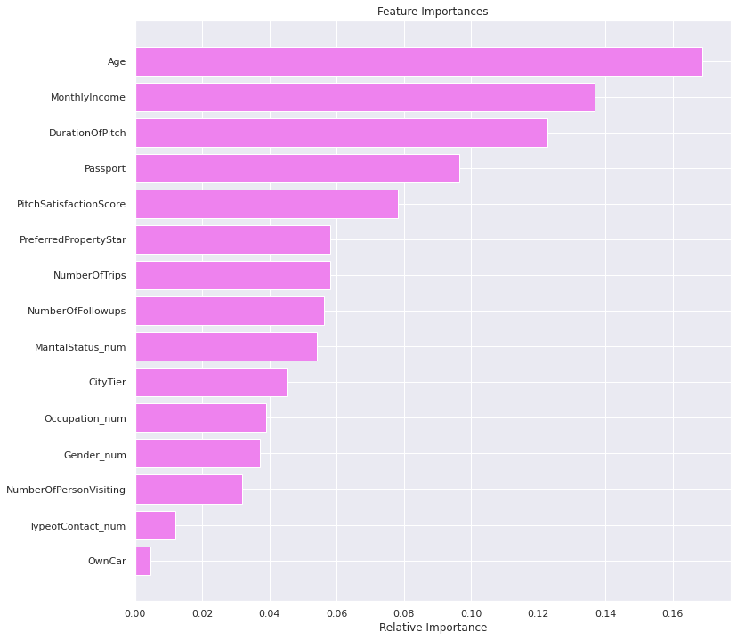

```python
# Now let's identify and plot the most significant features that are influencing the predicted results
show_top_features(dtree_tuned.feature_importances_)
```

This shows that the top 5 significant features in order of importance are:

1. Age
2. monthly income of customer
3. duration of the pitch given to the customer
4. the existence of a passport
5. the pitch satisfaction score.

## **Bagging Model**

```python
bg_estimator=BaggingClassifier(random_state=1)
bg_estimator.fit(X_train,y_train)
```

```
BaggingClassifier(base_estimator=None, bootstrap=True, bootstrap_features=False,
                  max_features=1.0, max_samples=1.0, n_estimators=10,
                  n_jobs=None, oob_score=False, random_state=1, verbose=0,
                  warm_start=False)
```

```python
# Analyze the effectiveness of the model
bg_score=get_model_score(bg_estimator, False)
```

```
Training Set >>>>
       Accuracy: 0.9905465288035451
       Recall: 0.9518633540372671
       Precision: 0.998371335504886
       F1: 0.9745627980922098
       R-square: 0.938635987681877
       RMSE: 0.0972289627449298
Test Set >>>>
       Accuracy: 0.9139118457300276
       Recall: 0.599250936329588
       Precision: 0.898876404494382
       F1: 0.7191011235955056
       R-square: 0.42634997392499874
       RMSE: 0.29340782925813763
```

Once again we have a model that is overfitting the training data, although it's performance is better than the decision tree we had initially received. Still recall for training data is 0.95 whereas recall for test data is a mere 0.599.

We need to find a better model.

### **Hyperparameter Tuning**

```python
# Choose the type of classifier.
bagging_tuned = BaggingClassifier(random_state=1)

# Grid of parameters to choose from
## add from article
parameters = {'max_samples': [0.7,0.8,0.9,1],
              'max_features': [0.7,0.8,0.9,1],
              'n_estimators' : [10,20,30,40,50],
             }

# Type of scoring used to compare parameter combinations
acc_scorer = metrics.make_scorer(metrics.recall_score)

# Run the grid search
grid_obj = GridSearchCV(bagging_tuned, parameters, scoring=acc_scorer,cv=5)
grid_obj = grid_obj.fit(X_train, y_train)

# Set the clf to the best combination of parameters
bagging_tuned = grid_obj.best_estimator_

# Fit the best algorithm to the data.
bagging_tuned.fit(X_train, y_train)
```

```
BaggingClassifier(base_estimator=None, bootstrap=True, bootstrap_features=False,
                  max_features=0.9, max_samples=0.9, n_estimators=40,
                  n_jobs=None, oob_score=False, random_state=1, verbose=0,
                  warm_start=False)
```

```python
# Analyze the effectiveness of the tuned model
bagging_tuned_score=get_model_score(bagging_tuned, False)
```

```
Training Set >>>>
       Accuracy: 0.9988183161004431
       Recall: 0.9937888198757764
       Precision: 1.0
       F1: 0.9968847352024921
       R-square: 0.9923294984602347
       RMSE: 0.03437562944233703
Test Set >>>>
       Accuracy: 0.9104683195592287
       Recall: 0.5805243445692884
       Precision: 0.8959537572254336
       F1: 0.7045454545454546
       R-square: 0.4034039728819987
       RMSE: 0.2992184493656288
```

The tuned bagging model is actually performing worse than the initial bagging model that we got earlier. The recall score on the training data has gone up and the recall score on the test data has gone down. The model is clearly overfitting the training model.

More work is needed before we can have a reliable model.

## **Random Forest Model**

```python
rf_estimator=RandomForestClassifier(random_state=1)
rf_estimator.fit(X_train,y_train)
```

```
RandomForestClassifier(bootstrap=True, ccp_alpha=0.0, class_weight=None,
                       criterion='gini', max_depth=None, max_features='auto',
                       max_leaf_nodes=None, max_samples=None,
                       min_impurity_decrease=0.0, min_impurity_split=None,
                       min_samples_leaf=1, min_samples_split=2,
                       min_weight_fraction_leaf=0.0, n_estimators=100,
                       n_jobs=None, oob_score=False, random_state=1, verbose=0,
                       warm_start=False)
```

```python
# Analyze the effectiveness of the model
rf_estimator_score=get_model_score(rf_estimator, False)
```

```
Training Set >>>>
       Accuracy: 1.0
       Recall: 1.0
       Precision: 1.0
       F1: 1.0
       R-square: 1.0
       RMSE: 0.0
Test Set >>>>
       Accuracy: 0.9146005509641874
       Recall: 0.5842696629213483
       Precision: 0.9230769230769231
       F1: 0.7155963302752294
       R-square: 0.4309391741335987
       RMSE: 0.29223184124221074
```

The random forest model is also clearly overfitting the training data, giving a poor score to the test data.

We need to try to improve the model.

### **Hyperparameter Tuning**

```python
# Choose the type of classifier.
rf_tuned = RandomForestClassifier(random_state=1)

# Grid of parameters to choose from
parameters = {
                'max_depth':[4, 6, 8, 10, None],
                'max_features': ['sqrt','log2',None],
                'n_estimators': [80, 90, 100, 110, 120]
}

# Type of scoring used to compare parameter combinations
scorer = metrics.make_scorer(metrics.r2_score)

# Run the grid search
grid_obj = GridSearchCV(rf_tuned, parameters, scoring=scorer,cv=5)
grid_obj = grid_obj.fit(X_train, y_train)

# Set the clf to the best combination of parameters
rf_tuned = grid_obj.best_estimator_

# Fit the best algorithm to the data.
rf_tuned.fit(X_train, y_train)
```

```
RandomForestClassifier(bootstrap=True, ccp_alpha=0.0, class_weight=None,
                       criterion='gini', max_depth=None, max_features=None,
                       max_leaf_nodes=None, max_samples=None,
                       min_impurity_decrease=0.0, min_impurity_split=None,
                       min_samples_leaf=1, min_samples_split=2,
                       min_weight_fraction_leaf=0.0, n_estimators=100,
                       n_jobs=None, oob_score=False, random_state=1, verbose=0,
                       warm_start=False)
```

```python
# Let's evaluate the tuned model
rf_tuned_score=get_model_score(rf_tuned, False)
```

```
Training Set >>>>
       Accuracy: 1.0
       Recall: 1.0
       Precision: 1.0
       F1: 1.0
       R-square: 1.0
       RMSE: 0.0
Test Set >>>>
       Accuracy: 0.9194214876033058
       Recall: 0.6441947565543071
       Precision: 0.8865979381443299
       F1: 0.7462039045553145
       R-square: 0.46306357559379885
       RMSE: 0.28386354538174535
```

The tuned model is still clearly overfitting the training data and giving poor results for the test data.

However, we do see that the recall scores in this case have improved compared to the initial Random Forest model that I had got. However, there is more work to be done to reduce the overfitting.

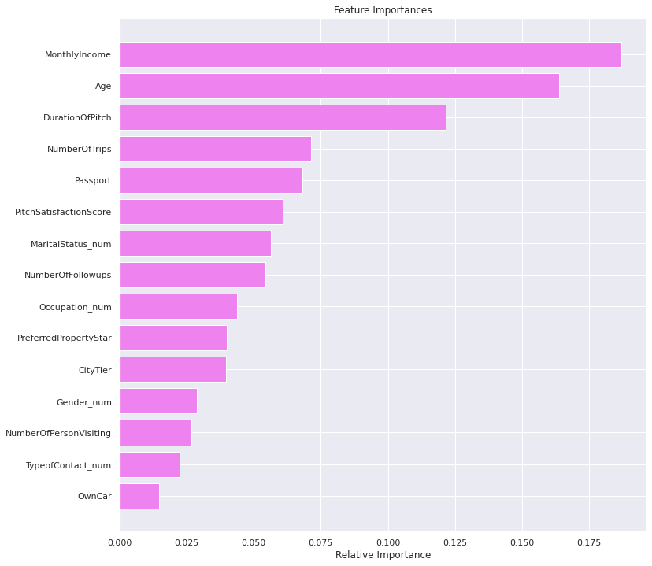

```python
# Now let's identify and plot the most significant features that are influencing the predicted results
show_top_features(rf_tuned.feature_importances_)
```

The top 5 features identified by this Random Forest model are:

1. Monthly income
2. Age
3. Duration of the pitch made to the customer
4. Number of trips (this is different from the Decision Tree model)
5. Existence of a passport.

# **Boosting Models**

## **AdaBoost Classifier**

```python
ab_estimator=AdaBoostClassifier(random_state=1)
ab_estimator.fit(X_train,y_train)
```

```
AdaBoostClassifier(algorithm='SAMME.R', base_estimator=None, learning_rate=1.0,
                   n_estimators=50, random_state=1)
```

```python
# Evaluate the effectiveness of the model
ab_estimator_score=get_model_score(ab_estimator, False)
```

```
Training Set >>>>
       Accuracy: 0.8508124076809453
       Recall: 0.36180124223602483
       Precision: 0.7125382262996942
       F1: 0.47991761071060757
       R-square: 0.0315991806046213
       RMSE: 0.3862480968484565
Test Set >>>>
       Accuracy: 0.8402203856749312
       Recall: 0.30337078651685395
       Precision: 0.6377952755905512
       F1: 0.4111675126903553
       R-square: -0.06469444839520233
       RMSE: 0.39972442297796723
```

The AdaBoost classifier is not overfitting the training data, and is giving pretty consistent result between the training data set and the testing data set.

However, the recall numbers are terrible -- 0.36 for training data, and 0.30 for test data.

We will try to find a better model.

### **Hyperparameter Tuning**

```python
# Choose the type of classifier.
ab_tuned = AdaBoostClassifier(random_state=1)

# Grid of parameters to choose from
parameters = {'n_estimators': np.arange(10,100,10),
              'learning_rate': [1, 0.1, 0.5, 0.01],
              }

# Type of scoring used to compare parameter combinations
scorer = metrics.make_scorer(metrics.r2_score)

# Run the grid search
grid_obj = GridSearchCV(ab_tuned, parameters, scoring=scorer,cv=5)
grid_obj = grid_obj.fit(X_train, y_train)

# Set the clf to the best combination of parameters
ab_tuned = grid_obj.best_estimator_

# Fit the best algorithm to the data.
ab_tuned.fit(X_train, y_train)
```

```
AdaBoostClassifier(algorithm='SAMME.R', base_estimator=None, learning_rate=0.5,
                   n_estimators=90, random_state=1)
```

```python
# Let's evaluate the tuned model
ab_tuned_score=get_model_score(ab_tuned, False)
```

```
Training Set >>>>
       Accuracy: 0.851698670605613
       Recall: 0.3198757763975155
       Precision: 0.762962962962963
       F1: 0.45076586433260396
       R-square: 0.03735205675944542
       RMSE: 0.3850991163251183
Test Set >>>>
       Accuracy: 0.8464187327823691
       Recall: 0.27340823970037453
       Precision: 0.7156862745098039
       F1: 0.3956639566395664
       R-square: -0.023391646517802345
       RMSE: 0.39189445928416855
```

The tuned model did not get any better. Although there is not much overfitting of training data, the recall score of 0.273 is really unreliable to make any prediction.

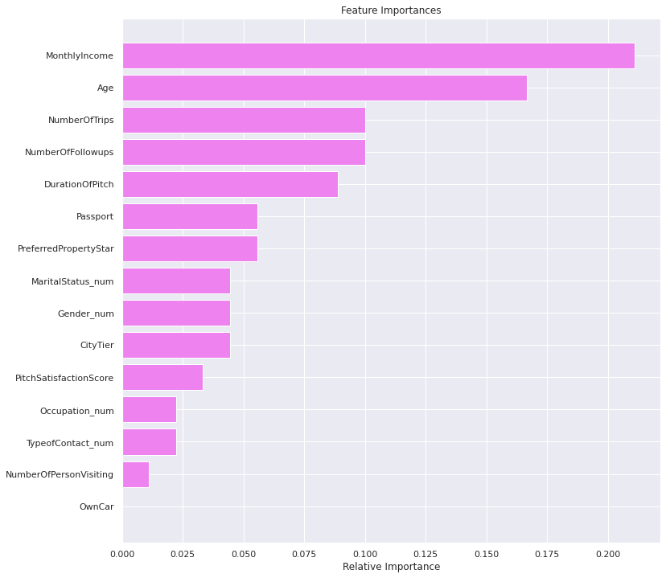

```python
# Now let's identify and plot the most significant features that are influencing the predicted results
show_top_features(ab_tuned.feature_importances_)
```

Even with the AdaBoost model, where the recall scores are so low, the top features remained consistent.

1. Monthly income
2. Age
3. Number of trips (this is new)
4. Number of followups
5. Duration of the pitch to the customers.

## **Gradient Boosting**

```python
gb_estimator=GradientBoostingClassifier(random_state=1)
gb_estimator.fit(X_train,y_train)
```

```
GradientBoostingClassifier(ccp_alpha=0.0, criterion='friedman_mse', init=None,
                           learning_rate=0.1, loss='deviance', max_depth=3,
                           max_features=None, max_leaf_nodes=None,
                           min_impurity_decrease=0.0, min_impurity_split=None,
                           min_samples_leaf=1, min_samples_split=2,
                           min_weight_fraction_leaf=0.0, n_estimators=100,
                           n_iter_no_change=None, presort='deprecated',
                           random_state=1, subsample=1.0, tol=0.0001,
                           validation_fraction=0.1, verbose=0,
                           warm_start=False)
```

```python
# Evaluate the effectiveness of the model
gb_classifier_score=get_model_score(gb_estimator, False)
```

```
Training Set >>>>
       Accuracy: 0.8833087149187593
       Recall: 0.453416149068323
       Precision: 0.8716417910447761
       F1: 0.5965270684371808
       R-square: 0.24253797294816914
       RMSE: 0.3416010612999333
Test Set >>>>
       Accuracy: 0.8629476584022039
       Recall: 0.3857677902621723
       Precision: 0.7463768115942029
       F1: 0.5086419753086419
       R-square: 0.08674915848859799
       RMSE: 0.37020580978395806
```

There is a little bit of overfitting of the training model going on here with the recall score for the training data being 0.45 and the recall score for test data being 0.385.

However, the overall recall numbers are far from satisfactory and we need to try to improve the model.

### **Hyperparameter Tuning**

```python
# Choose the type of classifier.
gb_tuned = GradientBoostingClassifier(random_state=1)

# Grid of parameters to choose from
parameters = {'n_estimators': np.arange(50,200,25),
              'subsample':[0.7,0.8,0.9,1],
              'max_features':[0.7,0.8,0.9,1],
              'max_depth':[3,5,7,10]
              }

# Type of scoring used to compare parameter combinations
scorer = metrics.make_scorer(metrics.r2_score)

# Run the grid search
grid_obj = GridSearchCV(gb_tuned, parameters, scoring=scorer,cv=5)
grid_obj = grid_obj.fit(X_train, y_train)

# Set the clf to the best combination of parameters
gb_tuned = grid_obj.best_estimator_

# Fit the best algorithm to the data.
gb_tuned.fit(X_train, y_train)
```

```
GradientBoostingClassifier(ccp_alpha=0.0, criterion='friedman_mse', init=None,
                           learning_rate=0.1, loss='deviance', max_depth=10,
                           max_features=0.7, max_leaf_nodes=None,
                           min_impurity_decrease=0.0, min_impurity_split=None,
                           min_samples_leaf=1, min_samples_split=2,
                           min_weight_fraction_leaf=0.0, n_estimators=150,
                           n_iter_no_change=None, presort='deprecated',
                           random_state=1, subsample=1, tol=0.0001,
                           validation_fraction=0.1, verbose=0,
                           warm_start=False)
```

```python
# Let's evaluate the effectiveness of the tuned model
gb_tuned_score=get_model_score(gb_tuned, False)
```

```
Training Set >>>>
       Accuracy: 1.0
       Recall: 1.0
       Precision: 1.0
       F1: 1.0
       R-square: 1.0
       RMSE: 0.0
Test Set >>>>
       Accuracy: 0.9325068870523416
       Recall: 0.6928838951310862
       Precision: 0.9203980099502488
       F1: 0.7905982905982906
       R-square: 0.5502583795571989
       RMSE: 0.25979436665882194
```

The tuned model (which took 29 minutes to process), is clearly overfitting the training data set. However, the recall score from the tuned model is significantly better at 0.69 compared to the initial model that gave a recall score of 0.386 on the test data.

This means that the tuning was effective, although it took such a long time to process.

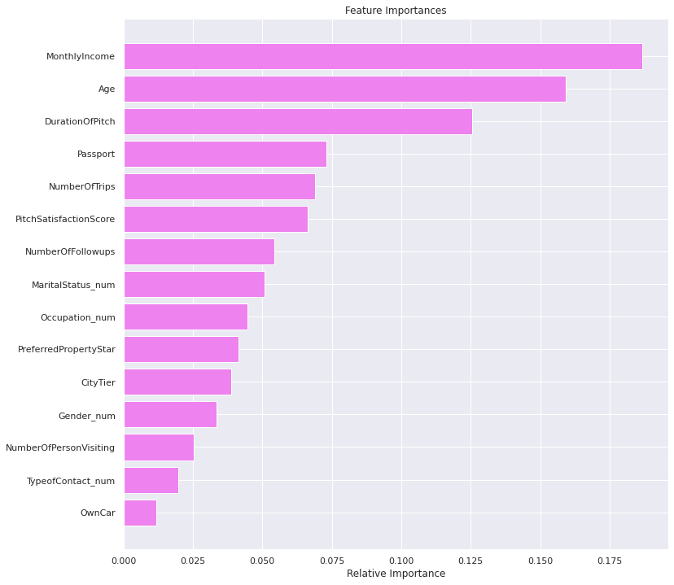

```python
# The most important features influencing the predictions from the Gradient Boosting model
show_top_features(gb_tuned.feature_importances_)
```

The most significant features affecting the prediction outcome are

1. Monthly income of the customers.
2. Age of customers
3. The duration for which sales pitches have been made.
4. The presence of a passport (means customer is ready to travel aborad).
5. The number of trips the customer has taken before.

## **XGBoost**

```python
xgb_estimator=XGBClassifier(random_state=1)
xgb_estimator.fit(X_train,y_train)
```

```
XGBClassifier(base_score=0.5, booster='gbtree', colsample_bylevel=1,
              colsample_bynode=1, colsample_bytree=1, gamma=0,
              learning_rate=0.1, max_delta_step=0, max_depth=3,
              min_child_weight=1, missing=None, n_estimators=100, n_jobs=1,
              nthread=None, objective='binary:logistic', random_state=1,
              reg_alpha=0, reg_lambda=1, scale_pos_weight=1, seed=None,
              silent=None, subsample=1, verbosity=1)
```

```python
# Evaluate the initial model
xgb_estimator_score=get_model_score(xgb_estimator, False)
```

```
Training Set >>>>
       Accuracy: 0.8768094534711964
       Recall: 0.42857142857142855
       Precision: 0.8492307692307692
       F1: 0.5696594427244581
       R-square: 0.20035021447945955
       RMSE: 0.3509851086995053
Test Set >>>>
       Accuracy: 0.8491735537190083
       Recall: 0.3146067415730337
       Precision: 0.7
       F1: 0.4341085271317829
       R-square: -0.005034845683402178
       RMSE: 0.3883638066053423
```

The inital XGBoost model does not have much overfitting of the training model, hence it is giving us consistent results with the test data as well.

However, the recall number from the test data is very low at 0.315, and this needs to be improved. We need to fine tune and get a better model for prediction.

### **Hyperparameter Tuning**

```python
# Choose the type of classifier.
xgb_tuned = XGBClassifier(random_state=1)

# Grid of parameters to choose from
parameters = {'n_estimators': [75,100,125,150],
              'subsample':[0.7, 0.8, 0.9, 1],
              'gamma':[0, 1, 3, 5],
              'colsample_bytree':[0.7, 0.8, 0.9, 1],
              'colsample_bylevel':[0.7, 0.8, 0.9, 1]
              }

# Type of scoring used to compare parameter combinations
scorer = metrics.make_scorer(metrics.r2_score)

# Run the grid search
grid_obj = GridSearchCV(xgb_tuned, parameters, scoring=scorer,cv=5)
grid_obj = grid_obj.fit(X_train, y_train)

# Set the clf to the best combination of parameters
xgb_tuned = grid_obj.best_estimator_

# Fit the best algorithm to the data.
xgb_tuned.fit(X_train, y_train)
```

```
XGBClassifier(base_score=0.5, booster='gbtree', colsample_bylevel=0.8,
              colsample_bynode=1, colsample_bytree=1, gamma=0,
              learning_rate=0.1, max_delta_step=0, max_depth=3,
              min_child_weight=1, missing=None, n_estimators=150, n_jobs=1,
              nthread=None, objective='binary:logistic', random_state=1,
              reg_alpha=0, reg_lambda=1, scale_pos_weight=1, seed=None,
              silent=None, subsample=0.7, verbosity=1)
```

```python
# Now let's measure the effectiveness of the tuned model
xgb_tuned_score=get_model_score(xgb_tuned, False)
```

```
Training Set >>>>
       Accuracy: 0.8901033973412112
       Recall: 0.4813664596273292
       Precision: 0.8908045977011494
       F1: 0.625
       R-square: 0.28664335680182007
       RMSE: 0.33150656503120535
Test Set >>>>
       Accuracy: 0.8636363636363636
       Recall: 0.3895131086142322
       Precision: 0.7482014388489209
       F1: 0.5123152709359605
       R-square: 0.09133835869719797
       RMSE: 0.3692744729379982
```

The tuned model has a better recall for the test data set at 0.389. This is not great either but it is better than the initial model. There is still a little bit of overfitting of the training data going on, but it is much less than some of the other models.

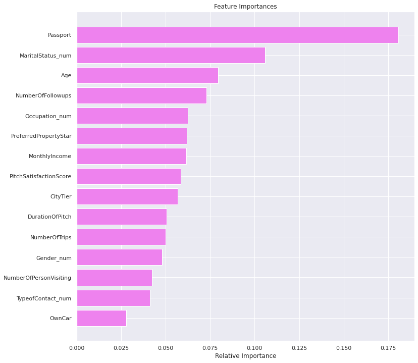

```python
# Now let's find the major features that influence the predictions from this model
show_top_features(xgb_tuned.feature_importances_)
```

According to this model, the most important features influencing the prediction outcome are

1. Presence of a passport (shows intent for international travel)
2. Marital status
3. Age
4. Number of followups from sales person
5. Occupation

## **Stacking**

Build a stacking model by using the tuned decision tree, tuned random forest, and the tuned gradient boost models. These will in turn be processed with an XGBClassifier.

```python
estimators=[('Decision Tree', dtree_tuned),('Random Forest', rf_tuned),
           ('Gradient Boosting', gb_tuned)]
final_estimator=XGBClassifier(random_state=1)
```

```python
stacking_estimator=StackingClassifier(estimators=estimators, final_estimator=final_estimator,cv=5)
stacking_estimator.fit(X_train,y_train)
```

```
StackingClassifier(cv=5,
                   estimators=[('Decision Tree',
                                DecisionTreeClassifier(ccp_alpha=0.0,
                                                       class_weight=None,
                                                       criterion='gini',
                                                       max_depth=10,
                                                       max_features=None,
                                                       max_leaf_nodes=None,
                                                       min_impurity_decrease=0.0,
                                                       min_impurity_split=None,
                                                       min_samples_leaf=1,
                                                       min_samples_split=2,
                                                       min_weight_fraction_leaf=0.0,
                                                       presort='deprecated',
                                                       random_state=1,
                                                       splitter='best')),
                               ('R...
                                                 colsample_bynode=1,
                                                 colsample_bytree=1, gamma=0,
                                                 learning_rate=0.1,
                                                 max_delta_step=0, max_depth=3,
                                                 min_child_weight=1,
                                                 missing=None, n_estimators=100,
                                                 n_jobs=1, nthread=None,
                                                 objective='binary:logistic',
                                                 random_state=1, reg_alpha=0,
                                                 reg_lambda=1,
                                                 scale_pos_weight=1, seed=None,
                                                 silent=None, subsample=1,
                                                 verbosity=1),
                   n_jobs=None, passthrough=False, stack_method='auto',
                   verbose=0)
```

```python
# Let's evaluate the score from the estimator
stacking_estimator_score=get_model_score(stacking_estimator, False)
```

```
Training Set >>>>
       Accuracy: 1.0
       Recall: 1.0
       Precision: 1.0
       F1: 1.0
       R-square: 1.0
       RMSE: 0.0
Test Set >>>>
       Accuracy: 0.928374655647383
       Recall: 0.6966292134831461
       Precision: 0.8899521531100478
       F1: 0.7815126050420169
       R-square: 0.522723178305599
       RMSE: 0.2676291171614499
```

## **Comparing All Models**

```python
# defining list of models
models = [dtree, dtree_tuned, bg_estimator, bagging_tuned, rf_estimator, rf_tuned, ab_estimator, ab_tuned, gb_estimator, gb_tuned, xgb_estimator,
         xgb_tuned, stacking_estimator]

# defining empty lists to add train and test results
r2_train = []
r2_test = []
rmse_train= []
rmse_test= []

# looping through all the models to get the rmse and r2 scores
for model in models:
    # accuracy score
    j = get_model_score(model,False)
    r2_train.append(j[0])
    r2_test.append(j[1])
    rmse_train.append(j[2])
    rmse_test.append(j[3])
```

```
Training Set >>>>
       Accuracy: 1.0
       Recall: 1.0
       Precision: 1.0
       F1: 1.0
       R-square: 1.0
       RMSE: 0.0
Test Set >>>>
       Accuracy: 0.8787878787878788
       Recall: 0.7191011235955056
       Precision: 0.6552901023890785
       F1: 0.6857142857142857
       R-square: 0.19230076328639822
       RMSE: 0.3481553119113957
Training Set >>>>
       Accuracy: 0.9488921713441655
       Recall: 0.7717391304347826
       Precision: 0.9502868068833652
       F1: 0.8517566409597258
       R-square: 0.6682508084051475
       RMSE: 0.22607040641321138
Test Set >>>>
       Accuracy: 0.8725895316804407
       Recall: 0.5917602996254682
       Precision: 0.6752136752136753
       F1: 0.6307385229540918
       R-square: 0.15099796140899813
       RMSE: 0.3569460299815075
Training Set >>>>
       Accuracy: 0.9905465288035451
       Recall: 0.9518633540372671
       Precision: 0.998371335504886
       F1: 0.9745627980922098
       R-square: 0.938635987681877
       RMSE: 0.0972289627449298
Test Set >>>>
       Accuracy: 0.9139118457300276
       Recall: 0.599250936329588
       Precision: 0.898876404494382
       F1: 0.7191011235955056
```

[output cut: 127 more lines]

```
       RMSE: 0.3692744729379982
Training Set >>>>
       Accuracy: 1.0
       Recall: 1.0
       Precision: 1.0
       F1: 1.0
       R-square: 1.0
       RMSE: 0.0
Test Set >>>>
       Accuracy: 0.928374655647383
       Recall: 0.6966292134831461
       Precision: 0.8899521531100478
       F1: 0.7815126050420169
       R-square: 0.522723178305599
       RMSE: 0.2676291171614499
```

```python
comparison_frame = pd.DataFrame({'Model':['Decision Tree','Tuned Decision Tree',
                                          'Bagging', 'Tuned Bagging',
                                          'Random Forest','Tuned Random Forest',
                                          'AdaBoost Classifier', 'Tuned AdaBoost Classifier',
                                          'Gradient Boosting Classifier', 'Tuned Gradient Boosting Classifier',
                                          'XGBoost Classifier',  'Tuned XGBoost Classifier','Stacking Classifier'],
                                          'Train_r2': r2_train,'Test_r2': r2_test,
                                          'Train_RMSE':rmse_train,'Test_RMSE':rmse_test})
comparison_frame
```

|  | Model | Train_r2 | Test_r2 | Train_RMSE | Test_RMSE |
| --- | --- | --- | --- | --- | --- |
| 0 | Decision Tree | 1.000000 | 0.192301 | 0.000000 | 0.348155 |
| 1 | Tuned Decision Tree | 0.668251 | 0.150998 | 0.226070 | 0.356946 |
| 2 | Bagging | 0.938636 | 0.426350 | 0.097229 | 0.293408 |
| 3 | Tuned Bagging | 0.992329 | 0.403404 | 0.034376 | 0.299218 |
| 4 | Random Forest | 1.000000 | 0.430939 | 0.000000 | 0.292232 |
| 5 | Tuned Random Forest | 1.000000 | 0.463064 | 0.000000 | 0.283864 |
| 6 | AdaBoost Classifier | 0.031599 | -0.064694 | 0.386248 | 0.399724 |
| 7 | Tuned AdaBoost Classifier | 0.037352 | -0.023392 | 0.385099 | 0.391894 |
| 8 | Gradient Boosting Classifier | 0.242538 | 0.086749 | 0.341601 | 0.370206 |
| 9 | Tuned Gradient Boosting Classifier | 1.000000 | 0.550258 | 0.000000 | 0.259794 |
| 10 | XGBoost Classifier | 0.200350 | -0.005035 | 0.350985 | 0.388364 |
| 11 | Tuned XGBoost Classifier | 0.286643 | 0.091338 | 0.331507 | 0.369274 |
| 12 | Stacking Classifier | 1.000000 | 0.522723 | 0.000000 | 0.267629 |

- Here the Tuned Gradient Boosting Classifier is giving us the best result with an R2 of 0.55 on the test data and an RMSE of 0.26.
- The top three models are the Tuned Gradient Boosting Classifier, the Stacking Classifier, and the Tuned Random Forest.

# **Recommendation To Business**

Although we did not get very good recall scores in any of the models, and there is some amount of overfitting going on with the training data set, some common themes have come out from all the models combined.